# STAA 566 HW#1

Lori Hernandez

**Introduction**

I am interested in hopefully one day working in the world of clean energy, possibly for the Department of Energy’s Clean Energy Corps; when given the opportunity to choose data to work with for this project, I wanted to select something clean-energy related. I found data sets on Kaggle that provide wind energy generation amounts for four different energy companies in Germany, and I thought this would be interesting data to use for this project. The data I used can be found at this link: https://www.kaggle.com/jorgesandoval/wind-power-generation

First, I will install the packages I will need to use for this project.

```r
knitr::opts_chunk$set(echo = TRUE)
install.packages("ggplot2", repos="http://cran.us.r-project.org")
install.packages("dplyr", repos="http://cran.us.r-project.org")
library(dplyr)
library(ggplot2)
```

Now I will load the 4 data sets I will use; there is a separate csv file for each of the 4 German energy companies. I will also add the name of the company to each data set, so that when I combine them I still can separate the data out by company.

```r
fifty_Hertz <- read.csv("C:/Users/lhern/OneDrive/Desktop/STAA 566/50Hertz.csv")
Amprion <- read.csv("C:/Users/lhern/OneDrive/Desktop/STAA 566/Amprion.csv")
TenneTTSO <- read.csv("C:/Users/lhern/OneDrive/Desktop/STAA 566/TenneTTSO.csv")
TransnetBW <- read.csv("C:/Users/lhern/OneDrive/Desktop/STAA 566/TransnetBW.csv")

#add name of energy company as a new column to each data set, so when I append them together I can tell which rows belong to which company
fifty_Hertz$Company <- "50Hertz"
Amprion$Company <- "Amprion"
TenneTTSO$Company <- "TenneTTSO"
TransnetBW$Company <- "TransnetBW"
```

Now I will combine the 4 data sets into one.

```r
wind <- rbind(fifty_Hertz, Amprion, TenneTTSO, TransnetBW)
```

Next I will complete some simple data cleaning tasks.

```r
#the date field loads into r with an additional symbol in the column name for the date parameter which will make code harder to read, so I will rename this column
names(wind)[names(wind) == "ï..Date"] <- "Date"

#the date field loads into r as a character string, but I want it to be a Date class; here I convert the Date column into Date data type
wind <- wind %>%
  mutate(Date = as.Date(Date, "%d/%m/%Y"))
```

The raw data provides an energy generation value for every 15 minute increment throughout each day; I want a total energy generation value for each full day, so I will sum these 96 values together to get a daily power generation value. Then, I will reduce my wind data set down to the name and date columns only, and combine those 2 columns with my newly created daily sum column, to have a 3 column data frame that provides only the company name, the date, and the sum of power generation for that date.

```r
a <- wind %>%
  select(starts_with("X"))
wind_daily_sum <- mutate(a, daily_sum=rowSums(a)) %>%
  select("daily_sum")
wind <- select(wind, Company, Date)
wind <- cbind(wind, wind_daily_sum)
```

Now that I have cleaned up and prepared my data, I will create my data visualization, which will show the daily wind power generated for each of the 4 German energy companies over time.

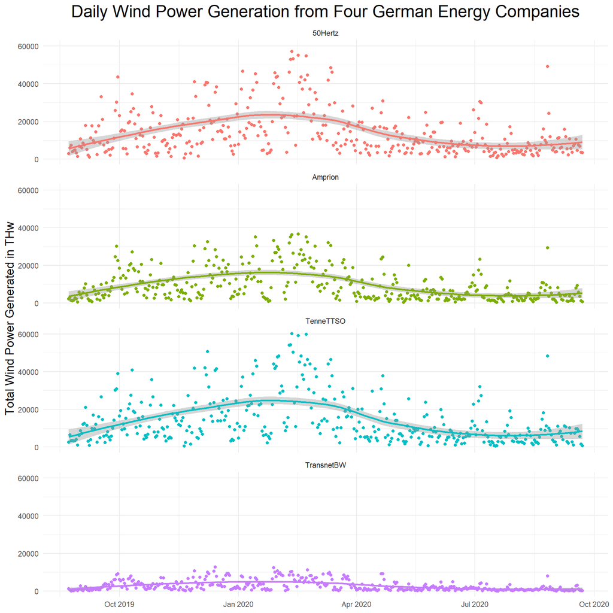

```r
my_visualization <- ggplot(wind, aes(Date, daily_sum, color=Company)) +
  geom_point() +
  geom_smooth() +
  facet_wrap(~Company, nrow=4) +
  labs(x=NULL, y="Total Wind Power Generated in THw") +
  ggtitle("Daily Wind Power Generation from Four German Energy Companies")+
  theme_minimal() +
  theme(plot.title = element_text(hjust = 0.5, size=20),
        axis.title.y = element_text(size=14),
        legend.position = "none")
my_visualization
```